# ¿Qué es CrossCarry?

Innovación estadística en R para el análisis de diseños crossover en salud y producción animal

Nelson Alirio Cruz

Facultad de Medicina Veterinaria y Zootecnia · UNAM

2026-10-27

[figure not shown]

## Ejemplo real

[video not shown]

## Datos iniciales

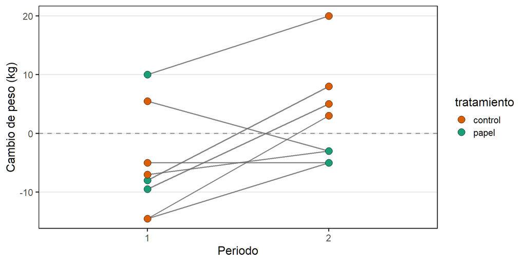

## Otros gráficos

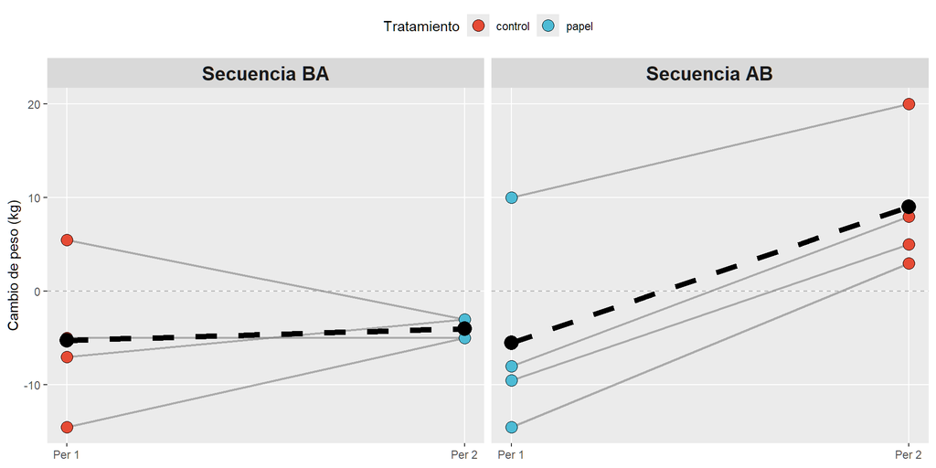

## Componentes de un diseño crossover

### Secuencias

Orden en el que los tratamientos son administrados: AB, BA

### Tratamientos

Intervenciones que se desean comparar: Dieta basada en pasto, Dieta basada en papel

### Períodos

Intervalos temporales en los que se aplican los tratamientos: Período 1, Período 2

### Unidades experimentales

Sujetos que reciben los tratamientos: Vacas

**Advertencia**

**Pero existe un desafío importante:** el efecto de un tratamiento puede persistir más allá del período en que fue administrado, generando **efectos residuales o carry-over** que pueden sesgar la comparación entre tratamientos.

## Tipos de efectos de arrastre (*carry-over*)

### Carry-over de primer orden

El efecto residual persiste durante el período inmediatamente posterior a la aplicación del tratamiento.

**Nota**

La respuesta observada en el período $t$ puede estar influenciada por el tratamiento administrado en el período $t-1$.

**Ejemplo**

Parte de la respuesta observada en el segundo período todavía puede reflejar el efecto de la dieta basada en papel.

### Carry-over de segundo orden

El efecto residual persiste durante dos períodos después de la aplicación del tratamiento.

**Nota**

La respuesta observada en el período $t$ puede estar influenciada por tratamientos administrados en los períodos $t-1$ y $t-2$.

**Ejemplo**

Con tres períodos, la respuesta observada en el Período 3 puede verse afectada por un tratamiento aplicado en el Período 1.

**Importante**

La identificación y modelización adecuada de los efectos de arrastre es fundamental para obtener estimaciones no sesgadas de los efectos de tratamiento en diseños crossover.

## Tipos de efectos de arrastre (*carry-over*)

### Carry-over simple

El efecto residual de un tratamiento es el mismo independientemente del tratamiento que se administre posteriormente.

**Nota**

El efecto remanente depende únicamente del tratamiento previo.

**Ejemplo**

El efecto residual de **A** es idéntico en: A → B; A → C; - A → D

### Carry-over complejo

El efecto residual depende tanto del tratamiento previo como del tratamiento posterior.

**Advertencia**

El efecto remanente puede variar según la combinación de tratamientos.

**Ejemplo**

El efecto residual de **A** puede ser distinto en: A → B; A → C; A → D

**Importante**

**Pregunta clave:** ¿el tratamiento A deja siempre la misma “huella” o esta depende del tratamiento que se aplique después?

## Primer paso: modelos para respuestas no normales

La mayor parte de la literatura crossover ha estado enfocada en variables continuas y distribuciones normales.

Sin embargo, muchas aplicaciones generan: Conteos, Eventos, Número de éxitos, Respuestas binarias.

**Nota**

Antes de estudiar diseños más complejos, desarrollamos una metodología específica para diseños crossover con respuestas de la familia exponencial.

El objetivo era evaluar simultáneamente:

- Efectos de tratamiento
- Efectos de período
- Efectos de arrastre (*carry-over*)

## Un escenario simple

El trabajo se centró inicialmente en el caso más sencillo:

- Una observación por individuo y período.
- Diseños crossover clásicos (2×2 y extensiones).
- Posibles efectos de carry-over.
- Correlación entre mediciones repetidas del mismo individuo.
  $$Y_{ijt}\sim \text{Familia Exponencial}$$

Aunque la estructura parece simple, ignorar la dependencia temporal o los efectos residuales puede producir estimaciones sesgadas de los tratamientos.

**Advertencia**

La existencia de carry-over implica que la respuesta observada en un período puede depender también de tratamientos administrados previamente.

## ¿Por qué GEE y no GLMM?

### Ventajas de GEE

- Estima efectos promedio poblacionales.
- No requiere asumir una distribución para efectos aleatorios.
- Menor complejidad computacional.
- Inferencia robusta frente a errores en la estructura de correlación.
- Interpretación directa de los efectos marginales.
- Suele presentar mayor estabilidad en muestras pequeñas o moderadas.

### Ventajas de GLMM

- Permite modelar heterogeneidad entre individuos.
- Estima trayectorias específicas por sujeto.
- Maneja diseños desbalanceados de forma natural.
- Puede modelar estructuras jerárquicas complejas.
- Permite realizar predicciones individuales.
- Aprovecha información cuando existen muchas mediciones por sujeto.

## Limitaciones de cada aproximación

### Desventajas de GEE

- No modela explícitamente la variabilidad individual.
- Las predicciones para sujetos específicos son limitadas.
- La inferencia asintótica puede verse afectada con tamaños muestrales muy pequeños.
- Menos eficiente si la estructura de correlación está perfectamente especificada en un modelo mixto.

### Desventajas de GLMM

**Nota**

En este trabajo el interés principal era estimar correctamente los efectos de tratamiento, período y *carry-over* a nivel poblacional. Por ello se optó por una aproximación basada en **GEE**, incorporando explícitamente la correlación entre observaciones repetidas dentro de cada individuo.

## Análisis de diseños crossover con respuestas de la familia exponencial

Cruz, N. A., López Pérez, L. A. & Melo, O. O. (2023). *Analysis of cross-over experiments with count data in the presence of carry-over effects*. Statistica Neerlandica, 77(4), 516–542.

**Nota**

Se desarrolló un marco estadístico para analizar diseños crossover cuando la respuesta no es normal (por ejemplo, conteos Poisson) y pueden existir efectos de arrastre (*carry-over*).

- Incorporación explícita de efectos de tratamiento, período y carry-over.
- Modelización de la correlación entre observaciones del mismo individuo mediante **GEE**.
- Desarrollo de una tabla de análisis de desviancia análoga al ANOVA.
- Comparación entre modelos con y sin carry-over mediante criterios de ajuste.

### Resultado principal

Los estudios de simulación mostraron que ignorar los efectos de arrastre puede producir estimaciones sesgadas del efecto del tratamiento, mientras que la estrategia basada en GEE mantiene inferencias fiables incluso en presencia de carry-over.

## Limitaciones de las herramientas disponibles

Inicialmente se exploró el uso de los paquetes clásicos de R para GEE: `gee` y `geepack`.

**Advertencia**

La teoría desarrollada en nuestro artículo no solo modifica la ecuación de media incorporando efectos *carry-over*, sino que también deduce expresiones específicas para las matrices de covarianza y para la inferencia asociada a dichos efectos.

### Los paquetes disponibles:

- No incorporaban la parametrización específica de los efectos *carry-over*.
- No utilizaban las matrices de varianza deducidas para este tipo de diseños.

### Fue necesario programar:

- Las matrices de diseño para tratamientos, períodos y *carry-over*.
- Los algoritmos de estimación.
- Las matrices robustas de varianza.

**Importante**

La complejidad de estas implementaciones motivó posteriormente la creación de un paquete especializado que automatizara todo el flujo de análisis para diseños crossover.

## Nace CrossCarry

[figure not shown]

## Uso en un diseño sencillo

```r
library(CrossCarry)
datosV <- createCarry(Vacas, treatment = "tratamiento",
                      period = "periodo", id = "vaca", carrySimple = TRUE)
modelV <- CrossGEE(response = "pesodif",treatment = "tratamiento",
                   period = "periodo", id = "vaca", carry = datosV$carryover,
                   data=datosV$data, correlation = "unstructured" )
summary(modelV$model)
```

[output not shown]

## Correlación dentro de cada vaca

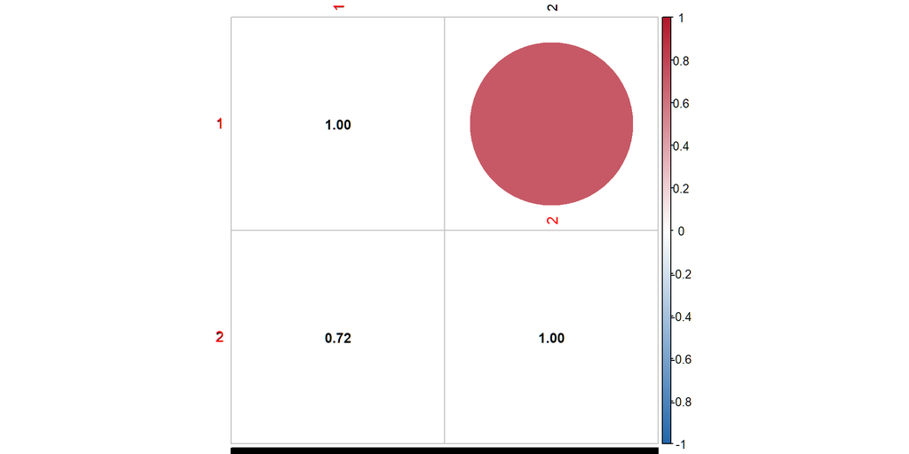

## ¿Y la producción de leche?

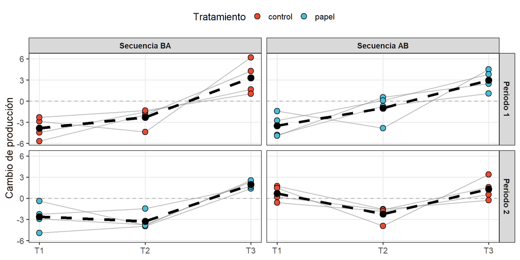

## Un modelo más complicado

```r
datosV <- createCarry(Vacas, treatment = "tratamiento",
                      period = "periodo", id = "vaca", carrySimple = TRUE)
modelV <- CrossGEE(response = "Proddif",treatment = "tratamiento",
                   period = "periodo", id = "vaca", carry = datosV$carryover,
                   covar = "tiempo", data=datosV$data, correlation = "unstructured" )
summary(modelV$model)
```

```
 GEE:  GENERALIZED LINEAR MODELS FOR DEPENDENT DATA
 gee S-function, version 4.13 modified 98/01/27 (1998)

Model:
 Link:                      Identity
 Variance to Mean Relation: Gaussian
 Correlation Structure:     Unstructured

Call:
gee::gee(formula = form1, id = id, data = data, family = family,
    corstr = correlation, Mv = Mv)

Summary of Residuals:
       Min         1Q     Median         3Q        Max
-4.2659060 -1.8170040 -0.3564918  1.0079663  5.0861158


Coefficients:
                   Estimate Naive S.E.   Naive z Robust S.E.  Robust z
(Intercept)      -4.3263258 0.46888042 -9.226928  0.48248414 -8.966773
periodo2         -1.5077898        NaN       NaN  0.27780993 -5.427415
tratamientopapel  1.1154251 0.05582189 19.981860  0.25640336  4.350275
Carry_papel       2.1342884        NaN       NaN  0.57516407  3.710747
tiempo            0.1295288 0.01693262  7.649662  0.02086786  6.207095

Estimated Scale Parameter:  5.172767
Number of Iterations:  25

Working Correlation
           [,1]         [,2]       [,3]         [,4]       [,5]         [,6]
[1,]  1.0000000  0.290979386 -0.3273672 -0.758698537  0.8232883 -0.090392895
[2,]  0.2909794  1.000000000 -0.8613904 -0.147644765  0.7204599  0.005427088
[3,] -0.3273672 -0.861390388  1.0000000 -0.120809372 -0.8945614  0.310012502
[4,] -0.7586985 -0.147644765 -0.1208094  1.000000000 -0.6755981  0.002232974
[5,]  0.8232883  0.720459923 -0.8945614 -0.675598120  1.0000000 -0.334178598
[6,] -0.0903929  0.005427088  0.3100125  0.002232974 -0.3341786  1.000000000
```

## Estructura de correlación

```r
datosV <- createCarry(Vacas, treatment = "tratamiento",
                      period = "periodo", id = "vaca", carrySimple = TRUE)
modelV <- CrossGEE(response = "Proddif",treatment = "tratamiento",
                   period = "periodo", id = "vaca", carry = datosV$carryover,
                   covar = "tiempo", data=datosV$data, correlation = "AR-M" )
summary(modelV$model)
```

```
 GEE:  GENERALIZED LINEAR MODELS FOR DEPENDENT DATA
 gee S-function, version 4.13 modified 98/01/27 (1998)

Model:
 Link:                      Identity
 Variance to Mean Relation: Gaussian
 Correlation Structure:     AR-M , M = 1

Call:
gee::gee(formula = form1, id = id, data = data, family = family,
    corstr = correlation, Mv = Mv)

Summary of Residuals:
       Min         1Q     Median         3Q        Max
-3.7702095 -1.5019053 -0.1285622  1.2351217  4.7543786


Coefficients:
                   Estimate Naive S.E.   Naive z Robust S.E.  Robust z
(Intercept)      -5.7447288 0.86347548 -6.653031  0.61441747 -9.349879
periodo2         -1.0752641 0.64227558 -1.674148  0.45706932 -2.352519
tratamientopapel  0.6907479 0.64102071  1.077575  0.32358323  2.134684
Carry_papel       1.8666355 0.86925419  2.147399  0.42887643  4.352385
tiempo            0.1711988 0.02696444  6.349059  0.02288279  7.481552

Estimated Scale Parameter:  4.717445
Number of Iterations:  3

Working Correlation
             [,1]        [,2]        [,3]        [,4]        [,5]         [,6]
[1,]  1.000000000 -0.39344580  0.15479960 -0.06090525  0.02396292 -0.009428109
[2,] -0.393445801  1.00000000 -0.39344580  0.15479960 -0.06090525  0.023962916
[3,]  0.154799599 -0.39344580  1.00000000 -0.39344580  0.15479960 -0.060905252
[4,] -0.060905252  0.15479960 -0.39344580  1.00000000 -0.39344580  0.154799599
[5,]  0.023962916 -0.06090525  0.15479960 -0.39344580  1.00000000 -0.393445801
[6,] -0.009428109  0.02396292 -0.06090525  0.15479960 -0.39344580  1.000000000
```

## Correlación dentro de cada vaca

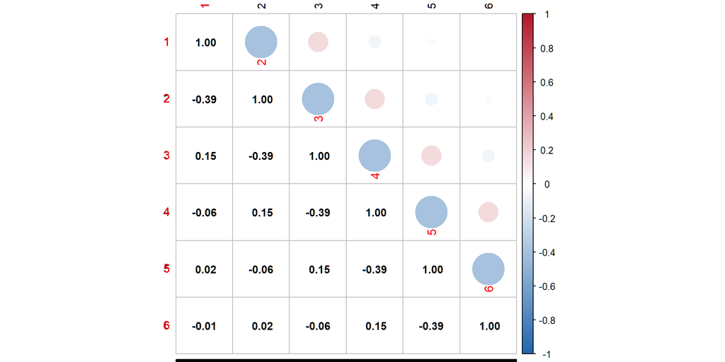

## Diseños crossover con medidas repetidas

Las observaciones presentan varios niveles de dependencia:

- Mediciones tomadas sobre el mismo individuo: Observaciones cercanas en el tiempo.
- Dependencia inducida por los tratamientos previamente administrados.

**Advertencia**

Las estructuras clásicas de correlación (independence, exchangeable, AR(1) o unstructured) asumen un único patrón de dependencia para todos los datos.

### Estructuras estándar

- Fáciles de implementar.
- Disponibles en software general.
- Pueden subestimar o sobreestimar la correlación entre observaciones.

### Estructura Kronecker

- Diferencia correlaciones dentro y entre períodos.
- Considera la secuencia de tratamientos.
- Admite medidas repetidas dentro de cada período.

## Matrices de correlación Kronecker

$$\mathbf{R}
=
\mathbf{R}_{P}
\otimes
\mathbf{R}_{T}
=
\begin{bmatrix}
1 & \rho_P \\
\rho_P & 1
\end{bmatrix}
\otimes
\begin{bmatrix}
1 & \rho_T & \rho_T^2 \\
\rho_T & 1 & \rho_T \\
\rho_T^2 & \rho_T & 1
\end{bmatrix}$$

donde: $\mathbf{R}_{P}$: correlación entre períodos del diseño crossover. $\mathbf{R}_{T}$: correlación temporal entre mediciones repetidas dentro de cada período y $\otimes$ es el producto Kronecker.

**Nota**

Esta formulación permite separar simultáneamente la dependencia longitudinal de corto plazo y la dependencia generada por la estructura crossover.

**Importante**

La adaptación de esta estructura a diseños crossover y el desarrollo de sus resultados teóricos fueron presentados en:

**Cruz, Melo & Martínez (2024)**  
*A correlation structure for the analysis of Gaussian and non-Gaussian responses in crossover experimental designs with repeated measures*. *Statistical Papers*, 65, 263–290.

## Correlación de Kronecker

```r
datosV <- createCarry(Vacas, treatment = "tratamiento",
                      period = "periodo", id = "vaca", carrySimple = TRUE)
modelV <- CrossGEEKron(response = "Proddif",treatment = "tratamiento",
                   period = "periodo", id = "vaca", carry = datosV$carryover,
                   time = "tiempo", covar = "tiempo", data=datosV$data,
                   correlation = "AR-M" )
summary(modelV$model)
```

```
 GEE:  GENERALIZED LINEAR MODELS FOR DEPENDENT DATA
 gee S-function, version 4.13 modified 98/01/27 (1998)

Model:
 Link:                      Identity
 Variance to Mean Relation: Gaussian
 Correlation Structure:     Fixed

Call:
gee::gee(formula = form1, id = id, data = data, R = RR, family = family,
    corstr = "fixed")

Summary of Residuals:
      Min        1Q    Median        3Q       Max
-3.493681 -1.212822  0.147430  1.520125  5.022350


Coefficients:
                   Estimate Naive S.E.   Naive z Robust S.E.  Robust z
(Intercept)      -5.8620375 0.76641869 -7.648610  0.66421540 -8.825507
periodo2         -1.0392182 0.52508401 -1.979146  0.48002368 -2.164931
tratamientopapel  0.5893729 0.52508401  1.122435  0.32310968  1.824065
Carry_papel       1.7718119 0.79520791  2.228112  0.49412200  3.585778
tiempo            0.1676116 0.02394565  6.999668  0.02354021  7.120226

Estimated Scale Parameter:  4.775858
Number of Iterations:  2

Working Correlation
            [,1]        [,2]        [,3]        [,4]        [,5]        [,6]
[1,]  1.00000000 -0.58596060  0.34334983  0.14676331 -0.08599752  0.05039116
[2,] -0.58596060  1.00000000 -0.58596060 -0.08599752  0.14676331 -0.08599752
[3,]  0.34334983 -0.58596060  1.00000000  0.05039116 -0.08599752  0.14676331
[4,]  0.14676331 -0.08599752  0.05039116  1.00000000 -0.58596060  0.34334983
[5,] -0.08599752  0.14676331 -0.08599752 -0.58596060  1.00000000 -0.58596060
[6,]  0.05039116 -0.08599752  0.14676331  0.34334983 -0.58596060  1.00000000
```

## Correlación entre periodos

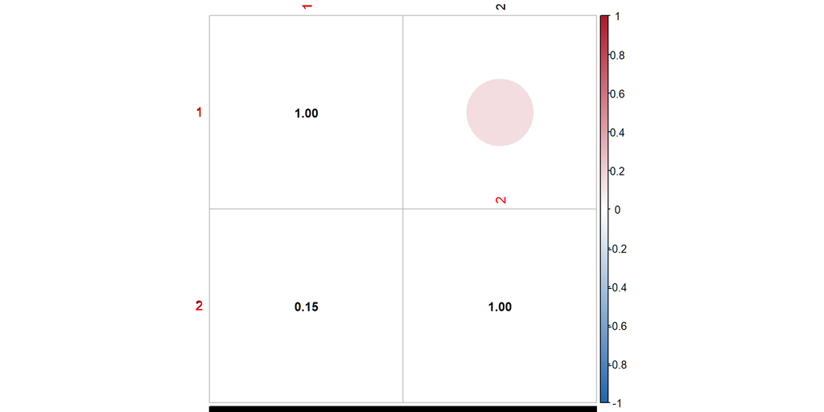

## Correlación dentro de periodos

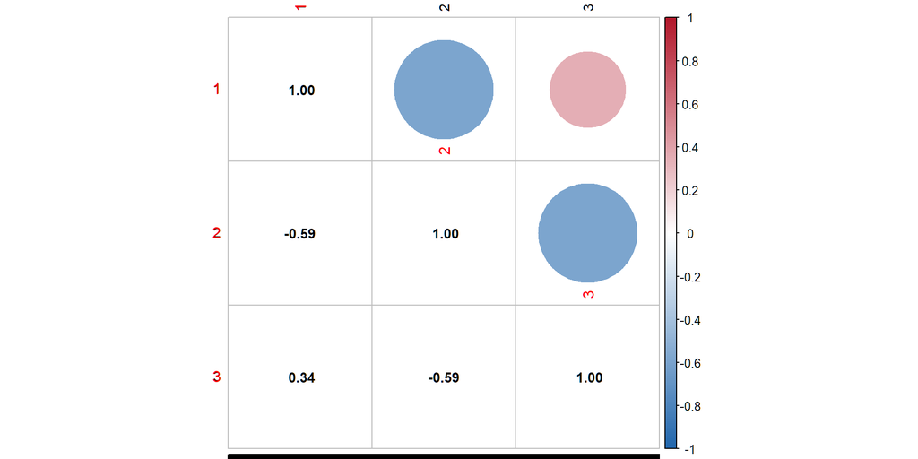

## Correlación de Kronecker

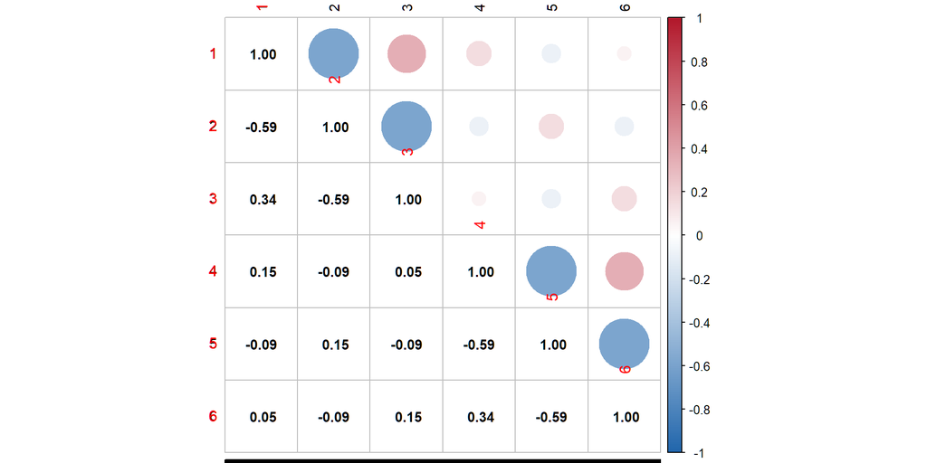

## Experimento de presión arterial

Los datos provienen de un estudio crossover con tres tratamientos antihipertensivos y medidas repetidas de presión arterial realizadas dentro de cada período experimental.

### Diseño

| Secuencia | Período 1 | Período 2 | Período 3 |
| --- | --- | --- | --- |
| ABC | $Y_{11}(t)$ | $Y_{12}(t)$ | $Y_{13}(t)$ |
| ACB | $Y_{21}(t)$ | $Y_{22}(t)$ | $Y_{23}(t)$ |
| BAC | $Y_{31}(t)$ | $Y_{32}(t)$ | $Y_{33}(t)$ |
| BCA | $Y_{41}(t)$ | $Y_{42}(t)$ | $Y_{43}(t)$ |
| CAB | $Y_{51}(t)$ | $Y_{52}(t)$ | $Y_{53}(t)$ |
| CBA | $Y_{61}(t)$ | $Y_{62}(t)$ | $Y_{63}(t)$ |

**Advertencia**

Dentro de cada periodo se están observando 10 mediciones de cada unidad experimental.

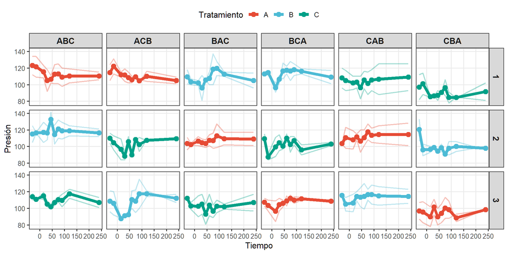

## ¿Por qué modelar el tiempo de forma no paramétrica?

La evolución temporal puede presentar:

- Descensos rápidos después de administrar el tratamiento.
- Estabilización en mediciones posteriores.
- Curvaturas, mesetas o cambios de pendiente.
- Perfiles temporales diferentes entre tratamientos.

**Advertencia**

Incluir el tiempo únicamente como un término lineal $\beta_t\,t,$ obliga a que la presión cambie a una tasa constante, lo cual puede no representar adecuadamente la respuesta observada.

### Modelo semiparamétrico

En lugar de imponer una forma específica, se incorpora una función suave del tiempo:

$$g\{\mu_{ijkt}\}
=
\mathbf{x}_{ijk}^{\mathsf T}\boldsymbol{\beta}
+
f(t),$$

donde:

- $\mathbf{x}_{ijk}^{\mathsf T}\boldsymbol{\beta}$ contiene los efectos de tratamiento, período y *carry-over*.
- $f(t)$ representa la trayectoria temporal estimada directamente a partir de los datos.

## Modelo GEE semiparamétrico para diseños crossover

Se desarrolló una extensión GEE, diseñada para analizar respuestas con medidas repetidas dentro de cada período.

### Componentes del modelo

- **Componente paramétrico** para estimar: Efectos de tratamiento, Efectos de período, Otras covariables de interés.
- **Componente no paramétrico** basado en *splines* para modelar: La evolución temporal de la respuesta, Los efectos *carry-over* variables en el tiempo.

### Propiedades encontradas

$$\sqrt{n}
\left(
\widehat{\boldsymbol{\beta}}-\boldsymbol{\beta}
\right)
\overset{d}{\longrightarrow}
N\left(
\mathbf{0},
\mathbf{A}^{-1}\mathbf{B}\mathbf{A}^{-1}
\right).$$

Estimación flexible de las funciones temporales mediante bases de *splines*

**Importante**

La adaptación de esta estructura a diseños crossover y el desarrollo de sus resultados teóricos fueron presentados en:

**Cruz, Melo & Martínez (2023)**  
Cruz Gutierrez, N. A., Melo, O. O., & Martinez, C. A. (2023).  
*Semiparametric generalized estimating equations for repeated measurements in cross-over designs*. *Statistical Methods in Medical Research*, **32**(5), 1033–1050.

## Un modelo menos sencillo

```r
data(Arterial)
carrydata <- createCarry(data=Arterial, treatment = "Treatment",
                         period = "Period",id="Subject", carrySimple = FALSE)
modelA <- CrossGEESP(response = "Pressure", treatment = "Treatment",
                    period = "Period", id="Subject", time="Time",
                    carry=carrydata$carryover,data=carrydata$data,
                    correlation = "AR-M")
```

```
 GEE:  GENERALIZED LINEAR MODELS FOR DEPENDENT DATA
 gee S-function, version 4.13 modified 98/01/27 (1998)

Model:
 Link:                      Identity
 Variance to Mean Relation: Gaussian
 Correlation Structure:     AR-M , M = 1

Call:
gee::gee(formula = form3, id = Per_id, data = dataTemp2, family = family,
    corstr = correlation)

Summary of Residuals:
       Min         1Q     Median         3Q        Max
-33.721967 -12.721967  -3.650402   5.026382  26.711095


Coefficients:
               Estimate Naive S.E.    Naive z Robust S.E.   Robust z
(Intercept) 111.0662659   2.377491 46.7157512    3.344520 33.2084365
Period2      -0.4330623   2.604411 -0.1662803    3.415246 -0.1268027
Period3      -1.4874283   2.604411 -0.5711190    3.610231 -0.4120036
TreatmentB    3.6557009   2.604411  1.4036576    3.006754  1.2158299
TreatmentC   -4.6052200   2.604411 -1.7682389    3.624211 -1.2706823

Estimated Scale Parameter:  114.8737
Number of Iterations:  2

Working Correlation
            [,1]       [,2]       [,3]       [,4]      [,5]      [,6]
 [1,] 1.00000000 0.66318517 0.43981456 0.29167849 0.1934369 0.1282844
 [2,] 0.66318517 1.00000000 0.66318517 0.43981456 0.2916785 0.1934369
 [3,] 0.43981456 0.66318517 1.00000000 0.66318517 0.4398146 0.2916785
 [4,] 0.29167849 0.43981456 0.66318517 1.00000000 0.6631852 0.4398146
 [5,] 0.19343685 0.29167849 0.43981456 0.66318517 1.0000000 0.6631852
 [6,] 0.12828445 0.19343685 0.29167849 0.43981456 0.6631852 1.0000000
 [7,] 0.08507634 0.12828445 0.19343685 0.29167849 0.4398146 0.6631852
 [8,] 0.05642137 0.08507634 0.12828445 0.19343685 0.2916785 0.4398146
 [9,] 0.03741782 0.05642137 0.08507634 0.12828445 0.1934369 0.2916785
[10,] 0.02481494 0.03741782 0.05642137 0.08507634 0.1282844 0.1934369
            [,7]       [,8]       [,9]      [,10]
 [1,] 0.08507634 0.05642137 0.03741782 0.02481494
 [2,] 0.12828445 0.08507634 0.05642137 0.03741782
 [3,] 0.19343685 0.12828445 0.08507634 0.05642137
 [4,] 0.29167849 0.19343685 0.12828445 0.08507634
 [5,] 0.43981456 0.29167849 0.19343685 0.12828445
 [6,] 0.66318517 0.43981456 0.29167849 0.19343685
 [7,] 1.00000000 0.66318517 0.43981456 0.29167849
 [8,] 0.66318517 1.00000000 0.66318517 0.43981456
 [9,] 0.43981456 0.66318517 1.00000000 0.66318517
[10,] 0.29167849 0.43981456 0.66318517 1.00000000
```

## Estimación de la función temporal $f(t)$

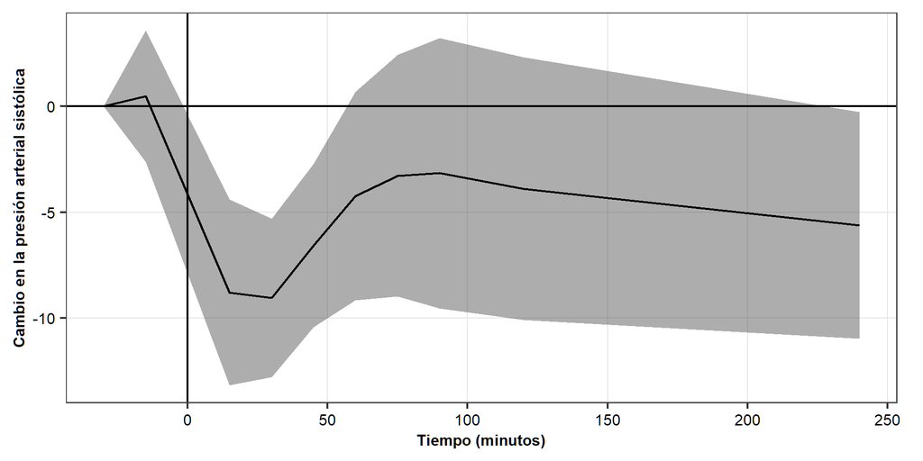

## Efecto *carry-over* de C sobre B

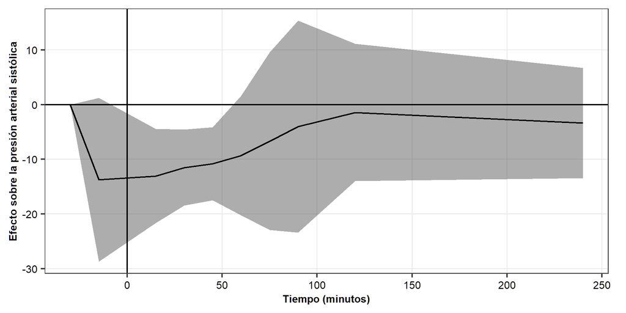

## Carry-over complejo y dependiente del tiempo

En este modelo, el efecto residual depende de dos elementos: El tratamiento administrado en el período anterior y El tratamiento recibido en el período actual. Por tanto, cada transición entre tratamientos tiene su propia función de *carry-over*:

### Efectos desde A y B

- $f_{A\rightarrow B}(t)$: efecto residual de A sobre B.
- $f_{A\rightarrow C}(t)$: efecto residual de A sobre C.
- $f_{B\rightarrow A}(t)$: efecto residual de B sobre A.
- $f_{B\rightarrow C}(t)$: efecto residual de B sobre C.

### Efectos desde C

- $f_{C\rightarrow A}(t)$: efecto residual de C sobre A.
- $f_{C\rightarrow B}(t)$: efecto residual de C sobre B.

**Advertencia**

$$f_{A\rightarrow B}(t)
\neq
f_{B\rightarrow A}(t)\neq f_{B\rightarrow C}(t)$$

**Importante**

No existe una única “huella” residual para cada tratamiento. La forma y magnitud del *carry-over* dependen de la transición específica y pueden cambiar a lo largo del tiempo.

## Un giro inesperado en la investigación

La incorporación de efectos *carry-over* complejos surgió en la etapa final de la tesis, a partir de una observación realizada durante la revisión del artículo.

**Advertencia**

Uno de los revisores señaló que asumir efectos *carry-over* simples podía ser poco realista en estudios farmacológicos, porque el efecto residual de un tratamiento no necesariamente es igual sobre todos los tratamientos posteriores.

Sin embargo, también existía una dificultad importante:

- El número de efectos aumentaba considerablemente.
- Con tres tratamientos se debían estimar seis transiciones distintas.
- Se esperaba que la falta de grados de libertad produjera problemas de identificabilidad o convergencia.
- Inicialmente, no estaba claro que el modelo pudiera estimarse con muestras pequeñas.

## ¿Qué se logró?

**Nota**

En ese momento conseguimos implementar los efectos *carry-over* complejos y el algoritmo logró converger con los datos reales.

Sin embargo, una solución computacional no garantizaba todavía que el método tuviera un buen comportamiento estadístico.

### Las incógnitas

- ¿Había suficientes grados de libertad?
- ¿El modelo estaba sobreparametrizado?
- ¿La convergencia se mantendría en otros escenarios?
- ¿Las seis funciones podían estimarse de forma estable?

### Lo que encontramos

- El algoritmo logró converger.
- Las funciones de *carry-over* pudieron estimarse.
- El procedimiento mostró estabilidad en simulación.
- El desempeño mejoró al aumentar las mediciones por período.

**Importante**

La implementación resolvió el problema inmediato, pero fue el estudio de simulación el que permitió comprobar que no se trataba únicamente de una convergencia afortunada: el modelo podía estimar efectos *carry-over* complejos y dependientes del tiempo con un buen comportamiento numérico.

## Un marco que reúne todo el desarrollo

Cruz, N. A., Melo, O. O., & Mylona, K. (2026). *Penalized GEE for Complex Carry-Over in Repeated-Measures Crossover Designs*. *Statistics in Medicine*, **45**(10–12), e70561.

### Fundamentos metodológicos

- **GEE** para considerar la correlación entre observaciones del mismo individuo.
- **Modelo semiparamétrico** para separar: Efectos de tratamiento y período, Evolución temporal de la respuesta, Efectos *carry-over* variables en el tiempo.
- **Carry-over complejo** específico para cada transición: $f_{g\rightarrow g'}(t).$

### Nuevos desarrollos

- Condiciones formales de **identificabilidad y estimabilidad**.
- Contracción de efectos residuales débiles hacia cero.
- Selección de la penalización mediante: QIC, Validación cruzada, Validación cruzada generalizada.

**Importante**

El nuevo marco reúne **GEE, modelización semiparamétrica, efectos carry-over complejos, bases funcionales y penalización** en una metodología general para diseños crossover con medidas repetidas.

## Aplicación: experimento en espacios de trabajo

El estudio evaluó cómo diferentes configuraciones de oficina afectaban la ocupación de los puestos de trabajo.

### Diseño experimental

- **288 participantes**, organizados en 22 equipos de trabajo.
- Cuatro grupos de aproximadamente 72 participantes.
- Diseño crossover de Williams:
  - 4 tratamientos.
  - 4 períodos.
  - 4 secuencias.
- Cada período tuvo una duración de **dos semanas**.
- Todos los grupos estuvieron expuestos a las cuatro configuraciones, pero en diferente orden.

### Configuraciones evaluadas

- **Control:** oficina abierta convencional.
- **Nest:** espacios de equipo más cerrados.
- **Menu:** oficina basada en actividades.
- **Campus:** oficina abierta dividida en zonas.

### Variable respuesta

La ocupación de las sillas se registró mediante sensores infrarrojos y se resumió en intervalos de cinco minutos $L=96$ mediciones repetidas por participante y período.

## Secuencias del diseño

| Grupo | Período 1 | Período 2 | Período 3 | Período 4 |
| --- | --- | --- | --- | --- |
| 1 | Control | Nest | Campus | Menu |
| 2 | Menu | Campus | Nest | Control |
| 3 | Campus | Control | Menu | Nest |
| 4 | Nest | Menu | Control | Campus |

**Importante**

El diseño garantiza que cada configuración aparezca una vez en cada período y que todas las transiciones dirigidas entre tratamientos estén representadas.

**Nota**

Con cuatro tratamientos existen $4(4-1)=12$ efectos *carry-over* complejos posibles. Las 96 mediciones dentro de cada período proporcionan la información temporal necesaria para estimar sus respectivas funciones.

## ¿Y por qué estoy hoy en la UNAM?

Esta historia comenzó cuando un investigador de la **UNAM**, que en ese momento se encontraba en **El Salvador**, utilizó `CrossCarry` para analizar un experimento crossover con vacas similar al nuestro.

Pero surgió un problema inesperado:

**Advertencia**

En sus datos, las vacas no estaban identificadas con números.

**¡Tenían nombres!** 🐄

```
 [1] "Palmera"  "Brisa"    "Appa"     "Miranda"  "Arrecha"  "Perlita"  "Certeza"  "Capilla"  "Zira"     "Burbuja"
[11] "Macarena" "Oluga"    "Boda"     "Avianca"  "Obrera"   "Pinta"    "Rumania"  "Pepita"   "Dina"     "Turca"
[21] "Púrpura"  "Marina"   "Mansa"    "Cremina"  "Gata"     "Cuaresma" "Café"     "Galanota" "Malabar"  "Orca"
[31] "Nucita"   "Ligia"    "Yara"     "Directa"  "Gaby"
```

El paquete asumía identificadores numéricos y no podía procesar correctamente esa estructura.

**Nota**

`CrossCarry` funcionaba con los datos para los que había sido desarrollado, pero necesitaba ser más flexible para responder a otras aplicaciones reales.

**Importante**

Esa consulta se convirtió en una colaboración, la colaboración ayudó a mejorar `CrossCarry` y, gracias a ese vínculo, hoy estoy presentando este trabajo en la **UNAM**.

## De un problema técnico a dos colaboraciones

Lo que comenzó con una dificultad para procesar los identificadores de las vacas terminó convirtiéndose en una colaboración científica.

**Nota**

`CrossCarry` permitió acompañar el análisis estadístico de dos experimentos crossover realizados con vacas lecheras en condiciones tropicales.

### Publicaciones resultantes

Corea Guillen, E. E., Flores Leiva, G. A., Mendoza, M. V., Ramirez-Perez, A. H., Lizarazo, A. C., Cruz, N. A., Castro-Montoya, J. M., Flores Santiago, E. J., & Ángeles-Hernandez, J. C. (2026).  
*Citrus pulp as an alternative energy source for high-yielding dairy cows in tropical systems: Effects on intake, digestibility, nitrogen balance, and dairy performance*.  
*Animals*, **16**(5), 806.  
https://doi.org/10.3390/ani16050806

Corea-Guillen, E. E., Flores, G. A., Molina, S. D., Mendoza, M. V., Ramirez-Perez, A. H., Lizarazo, A. C., Cruz Gutierrez, N. A., Castro-Montoya, J. M., Benaouda, M., & Angeles-Hernandez, J. C. (2025).  
*Effects of partial substitution of corn (Zea mays) silage with napier grass (Pennisetum purpureum) silage on nutrient use and performance of dairy cows in the tropics*.  
*Italian Journal of Animal Science*, **24**(1), 2334–2345.  
https://doi.org/10.1080/1828051X.2025.2578317

**Importante**

La mejora de una herramienta estadística no terminó únicamente en una nueva versión del paquete: abrió la puerta a nuevas preguntas, aplicaciones reales y colaboraciones científicas.

## CrossCarry: de la metodología al software

### ¿Qué reúne el paquete?

- Modelos basados en **GEE**.
- Efectos de tratamiento y período.
- Efectos *carry-over* simples y complejos.
- Modelos semiparamétricos mediante *splines*.
- Medidas repetidas dentro de cada período.
- Estructuras de correlación estándar y de Kronecker.
- Herramientas para crear variables de *carry-over*.
- Criterios para comparar modelos.

### Una herramienta reproducible

- Disponible como paquete de R.
- Documentación completa de las funciones.
- Ejemplos y conjuntos de datos.
- Código abierto.
- Validación de las entradas.
- Mensajes de error más informativos.
- Menor cantidad de código para el usuario.

```r
install.packages("CrossCarry")
library(CrossCarry)
```

## CrossCarry: de la metodología al software

**Importante**

`CrossCarry` transforma varios años de investigación estadística en una herramienta que otros investigadores pueden utilizar, verificar y extender.

### Publicación del software

Cruz, N. A., Melo, O. O., Martinez, C. A., & Alberich, R. (2026).  
*CrossCarry: An R package for the analysis of data from a crossover design with GEE*.  
*SoftwareX*, **33**, 102482.  
https://doi.org/10.1016/j.softx.2025.102482

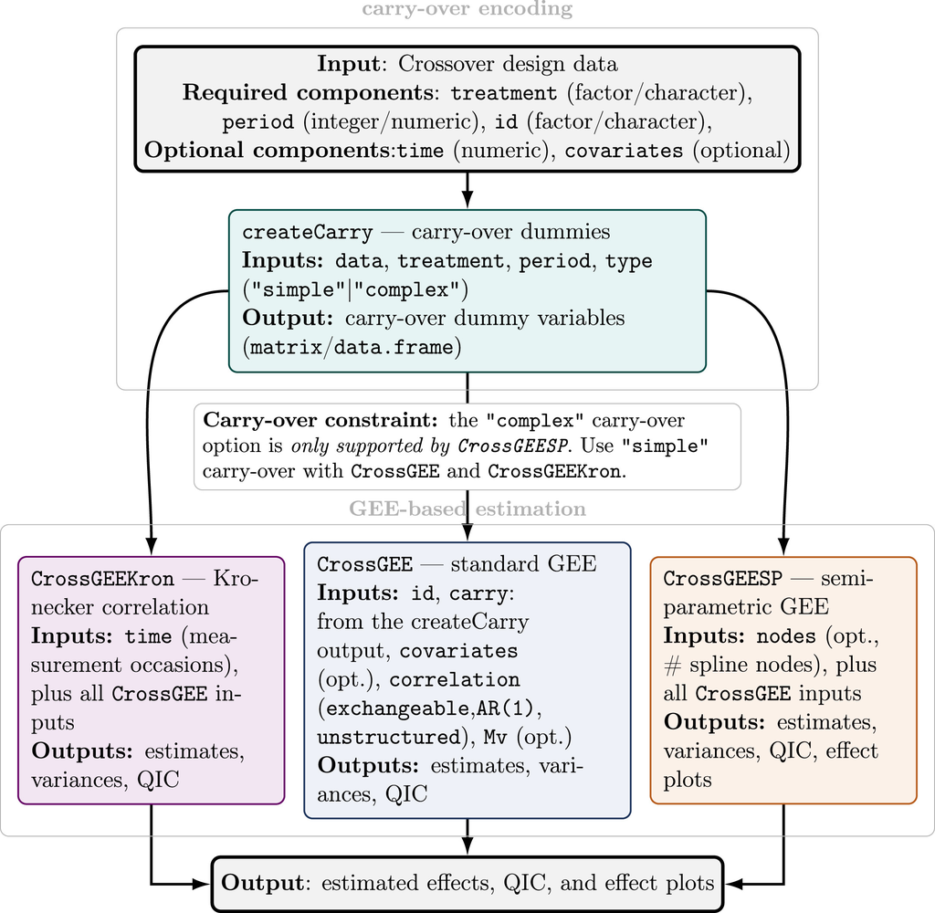